# *pitmastR*: an R-based pipeline to standardize processing of PIT tag data

# 1 Getting started with *pitmastr*

This document is a step-by-step guide to store and work with PIT tag data using ‘pitmastr’ package.

# 2 Load ‘pitmastr’ package

Step 1: Download all files from GitHub Repo: https://github.com/mkailing/pitmastr

Step 2: Install if needed and load to library ‘devtools’ package to access bundled pitmastr package from local drive or git repo

```r
# if devtools is not already installed, use:
# install.packages("devtools")

# else, load to library
library(devtools)
```

Step 3: Install and load bundled ‘pitmastR’ from zip file

```r
## for now DO THIS:

#devtools::install_local("/Users/mkailing/Dropbox/Kailing_Projects/pitmastr_0.1.0.tar.gz") #this should be path to zipped file with R package

# NOTE: If package dependencies need to be updated, enter '1'

#then, attach pitmastr to library
library(pitmastr)
```

# 3 Data management

## 3.1 File storage

The way detections on the reader are stored can vary depending on the model type and programmed settings. The folder structure we recommend accommodates most file types output by the readers. *See below for caveat regarding .accdb.

- Data downloaded as .log files are stored by date and then organized in folders by month.
- Newer systems and software allow for the export of several dates worth of detections into a single .txt or xlsx file.

*pitmastR* was created with this in mind and by storing as recommended, users can simultaneously assemble all detections from the various filetypes.

**Users with detections stored as .accdb files are encouraged to export the table from MS Access as a .xlsx to be compatible with master file assembly through ‘workhorse’*.

[figure not shown]

In our example above, there are multiple readers at a single site that need to remain distinct. Each reader is assigned a name that joins the site and entrance.

## 3.2 Map file formats

R objects are highly sensitive to date and time formats. To streamline data manipulations, prior to assembling or manipulating data, format your map files to ensure compatibility with subsequent data assembly functions. The data should be in long format for ease of use. Below is an example of map file structures.

[figure not shown]

[figure not shown]

### 3.2.1 first, prepare your map1 file that contains reader information

‘format_map1’ requires 3 arguments:

- **path.csv**, the file path where the map1 file that contains the dates, serial numbers, and locations (e.g., site names) of the readers
- **date1**, column name of the deployment date of the readers at the site
- **date2**, column name of the ending date for the reader at the site

This function will default to the current date for end date if the reader is still active at a site. In instances where reader files only provide the last four digits of the serial number, format_m1 will backfill the first four with ‘9999.’ to ensure downstream compatibility.

```r
# read in first map file (m1) and auto format with format_map1 function
m1 <- format_m1(path.csv = "/Users/mkailing/Dropbox/Kailing_Projects/pitmastr/inst/demo_dat/sn_map_demo.csv",
                  date1 = start,
                  date2 = end)
#check dataframe
head(m1); tail(m1)
```

```
##   start.date   end.date serial.num           test.tag reader site ent..old.
## 1 2020-08-25 2023-05-15  1929.3116 P_999.000000007425  MAOC1 MAOC         1
## 2 2023-07-26 2023-08-29  2032.3566 P_999.000000007429  MAOC1 MAOC         1
## 3 2023-08-29 2025-06-02  2032.3566 P_999.000000007429  MAOC1 MAOC         1
## 4 2020-08-16 2023-07-10  1929.3117 P_999.000000007425  MAOC2 MAOC         2
## 5 2023-08-03 2023-08-26  2151.4344 P_999.000000007425  MAOC2 MAOC         2
## 6 2023-08-29 2025-06-02  2326.5081 P_999.000000007425  MAOC2 MAOC         2
##   ent..new. part.sn
## 1         2    3116
## 2         2    3566
## 3         2    3566
## 4         1    3117
## 5         1    4344
## 6         1    5081
```

```
##    start.date   end.date serial.num           test.tag reader site ent..old.
## 23 2021-08-19 2021-10-03  2032.3565 P_999.000000007426  NEIN5 NEIN         5
## 24 2021-10-04 2025-06-02  2132.4200 P_999.000000007425  NEIN5 NEIN         5
## 25 2023-09-08 2025-06-02  9999.5167 P_999.000000007425  CLTO1 CLTO         1
## 26 2023-10-23 2025-06-02  9999.1527 P_999.000000007425  HAES1 HAES         1
## 27 2024-09-01 2025-06-02  2420.5692 P_999.000000007425  BAON1 BAON         1
## 28 2024-09-01 2025-06-02  2420.5690 P_999.000000007425  BAON2 BAON         2
##    ent..new. part.sn
## 23         3    3565
## 24         3    4200
## 25         1    5167
## 26         1    1527
## 27      <NA>    5692
## 28      <NA>    5690
```

### 3.2.2 second, prepare your map2 file that contains biological data associated with individuals

- **path.csv**, the file path including the name of the map2 file that contains the biological data
- **date1**, column name of the sampling dates (or start dates) of the readers at the respective site
- **id.colname**, column name that contains pit tag IDs
- **keep.cols**, combined list of columns that should be retained

```r
# read in second map file (m2) and auto format with format_map2 function
m2 <- format_m2(path.csv = "/Users/mkailing/Dropbox/Kailing_Projects/pitmastr/inst/demo_dat/bio_map_demo.csv",
                           date1 = date,
                           id.colname = id,
                           keep.cols = c(sex, species, age, mass, site))

# check dataframe
head(m2); tail(m2)
```

```
## # A tibble: 6 × 8
##   date.tagged         id              sex   species age    mass site  samp.event
##   <dttm>              <chr>           <chr> <chr>   <chr> <dbl> <chr>      <int>
## 1 2019-11-05 00:00:00 P_989.00100459… M     MYLU    ""       NA BAIT           1
## 2 2019-11-05 00:00:00 P_989.00100459… F     MYLU    "A"      NA BAIT           1
## 3 2019-11-05 00:00:00 P_989.00100459… M     MYLU    "J"      NA BAIT           1
## 4 2019-11-05 00:00:00 P_989.00100459… M     MYLU    "A"      NA BAIT           1
## 5 2019-11-05 00:00:00 P_989.00100459… M     MYLU    "A"      NA BAIT           1
## 6 2019-11-05 00:00:00 P_989.00100459… M     MYLU    "A"      NA BAIT           1
```

```
## # A tibble: 6 × 8
##   date.tagged         id              sex   species age    mass site  samp.event
##   <dttm>              <chr>           <chr> <chr>   <chr> <dbl> <chr>      <int>
## 1 2024-08-29 00:00:00 P_989.00104120… "F"   MYLU    "A"    8.07 NEIN           1
## 2 2024-08-29 00:00:00 P_989.00104120… "F"   MYLU    "A"    9.3  NEIN           1
## 3 2024-08-29 00:00:00 P_989.00104120… "F"   MYLU    "J"    8.23 NEIN           1
## 4 2024-08-29 00:00:00 P_989.00104120… "M"   EPFU    "A"   16.6  NEIN           1
## 5 2024-08-29 00:00:00 P_989.00104120… "M"   EPFU    "A"   14.5  NEIN           1
## 6 NA                  P_989.00103417… ""    MYLU    ""    NA    BAIT           1
```

Double check that id format is consistent with that of reader files. In our example, id contains a prefix “P_” that is inconsistent with files from reader. So, we remove here for all columns containg tag IDs in each map file.

```r
m1 %>%
  mutate(test.tag = gsub('P_', "", test.tag)) -> m1
m2 %>%
  mutate(id = gsub('P_', "", id)) -> m2
```

# 4 Data assembly

The first family of functions in *pitmastR* used to wrangle data stored in PIT tag files are assemblRs. The primary data assembly function (‘workhorse’) will search the user specified directory (path) to find all files output by readers, extract the detections from those files and serial numbers of readers, and assemble them in a master dataframe that can be exported or manipulated subsequently. Objects returned from any of the assembly functions will have shared structure, so they can be combined easily using ‘rbind’ in base R.

## 4.1 Assemble data…

### 4.1.1 with **‘workhorse’**

The ‘workhorse’ function searches all folders for each file type that can be exported by the readers within the specified directory. After extracting the rows from each file containing detections iteratively, ‘workhorse’ returns a list object of two data frames. The first contains all the detections with reader information provided in m1. The second returns a data frame containing only detections of test tags. This object will be used to evaluate reader operation and create survival object. ‘workhorse’ requires three arguments:

- **path**, the directory containing folders that store files downloaded from readers
- **string**, the shared prefix/suffix appended to all parent folders
- **map.file1**, the name of an object created using ‘format_map1’

and a fourth argument is optional:

- **remove.dup**, specify whether duplicated detections should be dropped from master dataframe once assembled (i.e., if one row is an exact match to another).
  - This argument defaults to “N”, such that all rows will be retained even if exact matches exist.
  - In most instances, duplicated rows are an artifact of accidentally duplicated data; ‘remove.dup=“Y”’ is strongly suggested.

In our example dataset, the highest folders are the primary site names. Within them, the *parent folders* contain the prefix “LOGGER_”, which is the pattern we call to the function indicating which folders to search for files containing detections from readers. The path up to the parent folder name will be included as a column in the returned object.

```r
pit_mastr <- workhorse(directory = "/Users/mkailing/Dropbox/Kailing_Projects/pitmastr/inst/demo_dat",
                string="LOGGER",
                map.file1 = m1,
                remove.dup = TRUE)

# check dataframes
head(pit_mastr[[1]]); tail(pit_mastr[[1]])
```

```
## # A tibble: 6 × 15
## # Groups:   serial.num [1]
##   start.date          end.date            serial.num test.tag       reader site
##   <dttm>              <dttm>              <chr>      <chr>          <chr>  <chr>
## 1 2020-08-24 00:00:00 2023-05-25 00:00:00 1929.3114  999.000000007… BAIT2  BAIT
## 2 2020-08-24 00:00:00 2023-05-25 00:00:00 1929.3114  999.000000007… BAIT2  BAIT
## 3 2020-08-24 00:00:00 2023-05-25 00:00:00 1929.3114  999.000000007… BAIT2  BAIT
## 4 2020-08-24 00:00:00 2023-05-25 00:00:00 1929.3114  999.000000007… BAIT2  BAIT
## 5 2020-08-24 00:00:00 2023-05-25 00:00:00 1929.3114  999.000000007… BAIT2  BAIT
## 6 2020-08-24 00:00:00 2023-05-25 00:00:00 1929.3114  999.000000007… BAIT2  BAIT
## # ℹ 9 more variables: ent..old. <chr>, ent..new. <chr>, part.sn <chr>,
## #   date <date>, time <times>, id <chr>, path <chr>, source <chr>,
## #   reader2 <chr>
```

```
## # A tibble: 6 × 15
## # Groups:   serial.num [1]
##   start.date          end.date            serial.num test.tag       reader site
##   <dttm>              <dttm>              <chr>      <chr>          <chr>  <chr>
## 1 2020-09-02 00:00:00 2021-07-30 00:00:00 2032.3566  999.000000007… NEIN5  NEIN
## 2 2020-09-02 00:00:00 2021-07-30 00:00:00 2032.3566  999.000000007… NEIN5  NEIN
## 3 2020-09-02 00:00:00 2021-07-30 00:00:00 2032.3566  999.000000007… NEIN5  NEIN
## 4 2020-09-02 00:00:00 2021-07-30 00:00:00 2032.3566  999.000000007… NEIN5  NEIN
## 5 2020-09-02 00:00:00 2021-07-30 00:00:00 2032.3566  999.000000007… NEIN5  NEIN
## 6 2020-09-02 00:00:00 2021-07-30 00:00:00 2032.3566  999.000000007… NEIN5  NEIN
## # ℹ 9 more variables: ent..old. <chr>, ent..new. <chr>, part.sn <chr>,
## #   date <date>, time <times>, id <chr>, path <chr>, source <chr>,
## #   reader2 <chr>
```

If serial numbers are missing, users can pull the site or reader name from the file path in pit_mastr. In our example, we generated a reader2 column that was taken from pit_mastr[[i]]$path, and then we extracted site from it.

```r
# pit_mastr[[1]]$site.x1 = stringr::word(pit_mastr[[1]]$reader2, 1)
# pit_mastr[[2]]$site.x1 = stringr::word(pit_mastr[[2]]$reader2, 1)
```

## 4.2 Link individuals’ metrics to PIT detections using ‘integrate_bio’

The ‘integrate_bio’ function allows users to combine biological metadata on individuals to detections.

‘integrate_bio’ requires three arguments:

- **x**, the df containing detections (ie the first object in the ‘pit_mastr’ list)
- **y**, the map2 file, m2, containing individual metadata (i.e., species, sex, tag location, tag date) *Note*: only time-independent variables may properly match. Time-varying factors that get included, such as mass, may not be properly reflected with detection dates
- **joiner**, the name of the column containing PIT tag IDs that is shared between the master file and map file 2.

and an optional fourth argument: - **remove.tt**, removes any test tag detections

```r
pit_workr <- integrate_bio(pit_mastr[[1]],
                           m2,
                           joiner = 'id',
                           remove.tt = TRUE)

head(pit_workr); tail(pit_workr)
```

```
## # A tibble: 6 × 22
## # Groups:   serial.num [1]
##   start.date          end.date            serial.num test.tag      reader site.x
##   <dttm>              <dttm>              <chr>      <chr>         <chr>  <chr>
## 1 2020-08-24 00:00:00 2023-05-25 00:00:00 1929.3114  999.00000000… BAIT2  BAIT
## 2 2020-08-24 00:00:00 2023-05-25 00:00:00 1929.3114  999.00000000… BAIT2  BAIT
## 3 2020-08-24 00:00:00 2023-05-25 00:00:00 1929.3114  999.00000000… BAIT2  BAIT
## 4 2020-08-24 00:00:00 2023-05-25 00:00:00 1929.3114  999.00000000… BAIT2  BAIT
## 5 2020-08-24 00:00:00 2023-05-25 00:00:00 1929.3114  999.00000000… BAIT2  BAIT
## 6 2020-08-24 00:00:00 2023-05-25 00:00:00 1929.3114  999.00000000… BAIT2  BAIT
## # ℹ 16 more variables: ent..old. <chr>, ent..new. <chr>, part.sn <chr>,
## #   date <date>, time <times>, id <chr>, path <chr>, source <chr>,
## #   reader2 <chr>, date.tagged <dttm>, sex <chr>, species <chr>, age <chr>,
## #   mass <dbl>, site.y <chr>, samp.event <int>
```

```
## # A tibble: 6 × 22
## # Groups:   serial.num [1]
##   start.date          end.date            serial.num test.tag      reader site.x
##   <dttm>              <dttm>              <chr>      <chr>         <chr>  <chr>
## 1 2020-09-02 00:00:00 2021-07-30 00:00:00 2032.3566  999.00000000… NEIN5  NEIN
## 2 2020-09-02 00:00:00 2021-07-30 00:00:00 2032.3566  999.00000000… NEIN5  NEIN
## 3 2020-09-02 00:00:00 2021-07-30 00:00:00 2032.3566  999.00000000… NEIN5  NEIN
## 4 2020-09-02 00:00:00 2021-07-30 00:00:00 2032.3566  999.00000000… NEIN5  NEIN
## 5 2020-09-02 00:00:00 2021-07-30 00:00:00 2032.3566  999.00000000… NEIN5  NEIN
## 6 2020-09-02 00:00:00 2021-07-30 00:00:00 2032.3566  999.00000000… NEIN5  NEIN
## # ℹ 16 more variables: ent..old. <chr>, ent..new. <chr>, part.sn <chr>,
## #   date <date>, time <times>, id <chr>, path <chr>, source <chr>,
## #   reader2 <chr>, date.tagged <dttm>, sex <chr>, species <chr>, age <chr>,
## #   mass <dbl>, site.y <chr>, samp.event <int>
```

Now, pit_workr was returned as an isolated dataframe containing all detections of individuals and their associated biological data.

# 5 Data manipulation

This family of functions will create objects that users can use in simple statistical models and survival analyses.

- **x**, the df containing detections and desired grouping variables. In our example, we use the object returned from ‘integrate_bio’
- **obs.groups**, a list of column names by which the user wants data to be structured and summarized
- **obs.units**, the time unit by which to summarize observations
- **date.colname**, column name for date to summarize by

First, we can bundle observations by pit tag id, sex, and detection site, counting the number of days individuals were detected within weeks of the year.

```r
ids_wks <- bundle_by(x = pit_workr,
                             obs.groups =  c(id, sex, site.x),
                             obs.unit = "weeks",
                             date.colname = date)
head(ids_wks); tail(ids_wks)
```

```
## # A tibble: 6 × 7
## # Groups:   id, sex, site.x, lubridate::year(date), lubridate::month(date) [4]
##   id               sex   site.x `lubridate::year(date)` `lubridate::month(date)`
##   <chr>            <chr> <chr>                    <dbl>                    <dbl>
## 1 985.113005718428 <NA>  CLTO                      2023                       11
## 2 985.113005718428 <NA>  CLTO                      2024                        2
## 3 985.113005718428 <NA>  CLTO                      2024                        5
## 4 985.113005718428 <NA>  CLTO                      2024                        5
## 5 985.113005718428 <NA>  CLTO                      2024                        6
## 6 985.113005718428 <NA>  CLTO                      2024                        6
## # ℹ 2 more variables: `lubridate::week(date)` <dbl>, n.days <int>
```

```
## # A tibble: 6 × 7
## # Groups:   id, sex, site.x, lubridate::year(date), lubridate::month(date) [6]
##   id               sex   site.x `lubridate::year(date)` `lubridate::month(date)`
##   <chr>            <chr> <chr>                    <dbl>                    <dbl>
## 1 989.001041204976 <NA>  NEIN                      2023                        8
## 2 989.001041204976 <NA>  NEIN                      2023                        9
## 3 989.001041204985 F     NEIN                      2023                        9
## 4 989.002008941329 <NA>  CLTO                      2023                       10
## 5 989.002008941329 <NA>  HAES                      2023                       10
## 6 989.002008941329 <NA>  HAES                      2023                       12
## # ℹ 2 more variables: `lubridate::week(date)` <dbl>, n.days <int>
```

Then, we can use the same function to bundle by pit tag id, sex, and reader (rather than site-level), and count the number of days individuals were detected each month.

```r
ids_months <- bundle_by(x = pit_workr,
                        obs.groups = c(id, sex, reader2),
                        obs.unit = "months",
                        date.colname = date)
head(ids_months); tail(ids_months)
```

```
## # A tibble: 6 × 6
## # Groups:   id, sex, reader2, lubridate::year(date) [2]
##   id          sex   reader2 lubridate::year(date…¹ lubridate::month(dat…² n.days
##   <chr>       <chr> <chr>                    <dbl>                  <dbl>  <int>
## 1 985.113005… <NA>  CLTO L…                   2023                     11      1
## 2 985.113005… <NA>  CLTO L…                   2024                      2      1
## 3 985.113005… <NA>  CLTO L…                   2024                      5      2
## 4 985.113005… <NA>  CLTO L…                   2024                      6      3
## 5 985.113005… <NA>  CLTO L…                   2024                      7      7
## 6 985.113005… <NA>  CLTO L…                   2024                      8      2
## # ℹ abbreviated names: ¹`lubridate::year(date)`, ²`lubridate::month(date)`
```

```
## # A tibble: 6 × 6
## # Groups:   id, sex, reader2, lubridate::year(date) [4]
##   id          sex   reader2 lubridate::year(date…¹ lubridate::month(dat…² n.days
##   <chr>       <chr> <chr>                    <dbl>                  <dbl>  <int>
## 1 989.001041… <NA>  NEIN L…                   2023                      8      1
## 2 989.001041… <NA>  NEIN L…                   2023                      9      1
## 3 989.001041… F     NEIN L…                   2023                      9      1
## 4 989.002008… <NA>  CLTO L…                   2023                     10      1
## 5 989.002008… <NA>  HAES L…                   2023                     10      1
## 6 989.002008… <NA>  HAES L…                   2023                     12      1
## # ℹ abbreviated names: ¹`lubridate::year(date)`, ²`lubridate::month(date)`
```

# 6 Check status of readers

These functions are to evaluate the consistency (or identify gaps) in system operation, that will support the creation of survival objects (such that days when systems are running are considered a ‘sample event’).

```r
rdr_chk <- readr_check(pit_mastr[[2]],
                       sys.colname = reader,
                       date1 = date,
                       min.reads = 2)
```

‘readr_viz’ will output the dataframe object returned from readr_check as ggplot object. It requires 1 argument:

- **df**, name of the dataframe that summarizes test tags fired (e.g., the object returned using readr_check)

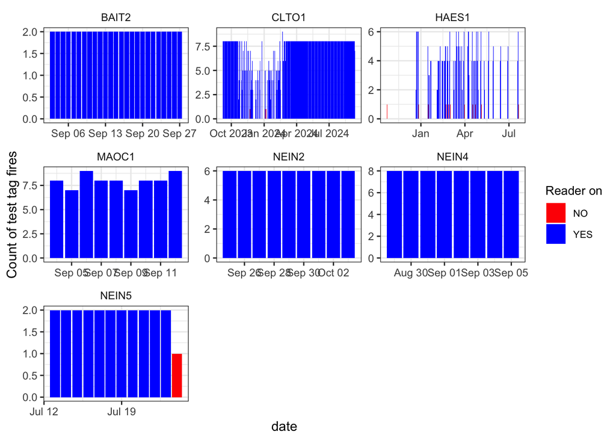

```r
rdr_viz <- readr_viz(rdr_chk)
```

# 7 Format dataframe for use in ‘survival’ package

pit_survival manipulates previously built data objects and integrates them to a single dataframe object. The returned objectis compatible with the ‘Surv’ function from the ‘survival’ package, which generates a survival object that can be used for estimating various survival curves.

‘pit_survival’ requires five arguments:

- **map.file1**, name of the dataframe object returned from format_m1
- **pit_workr**, name of the dataframe object containing detections and associated biological data
- **readr_check**, name of the dataframe object returned from ‘readr_check’ function
- **min.reads**, minimum number of daily test tag fires for a reader to be considered operational
- **min.detects**, number of times an individuals should be detected on a date to be considered ‘observed’

```r
pit_surv1 <- pit_survival(m1,
                          pit_workr,
                          readr_check = rdr_chk,
                          min.reads = 2,
                          min.detects = 1)
```

The returned object contains two estimates for ‘time’ that users can determine to be most useful.

- *time_since_lastobs* is the number of days since the last observation period, this number can be manipulated if users are interested in interval censored survival analyses
- *time_since_tagdate* is the number of days since the first observation (ie the individuals tag date)

```r
head(pit_surv1); tail(pit_surv1)
```

```
## # A tibble: 6 × 8
## # Groups:   id [4]
##   id               reader date                date.tagged         tot.dets
##   <chr>            <chr>  <dttm>              <dttm>                 <dbl>
## 1 989.001034203302 NEIN5  2021-07-13 00:00:00 2020-09-02 00:00:00        0
## 2 989.001034203268 NEIN5  2021-07-13 00:00:00 2020-09-02 00:00:00        0
## 3 989.001034203265 NEIN5  2021-07-13 00:00:00 2020-09-02 00:00:00        0
## 4 989.001034203245 NEIN5  2021-07-13 00:00:00 2020-09-02 00:00:00        0
## 5 989.001034203302 NEIN5  2021-07-14 00:00:00 2020-09-02 00:00:00        0
## 6 989.001034203268 NEIN5  2021-07-14 00:00:00 2020-09-02 00:00:00        0
## # ℹ 3 more variables: time_since_lastobs <dbl>, time_since_tagdate <dbl>,
## #   event <lgl>
```

```
## # A tibble: 6 × 8
## # Groups:   id [6]
##   id               reader date                date.tagged         tot.dets
##   <chr>            <chr>  <dttm>              <dttm>                 <dbl>
## 1 989.001041204607 NEIN4  2023-09-05 00:00:00 2023-08-28 00:00:00        0
## 2 989.001041204681 NEIN4  2023-09-05 00:00:00 2023-08-28 00:00:00        2
## 3 989.001041204985 NEIN4  2023-09-05 00:00:00 2023-08-28 00:00:00        1
## 4 989.001032566805 NEIN4  2023-09-05 00:00:00 2022-08-29 00:00:00        2
## 5 989.001041204668 NEIN4  2023-09-05 00:00:00 2023-08-28 00:00:00        1
## 6 989.001034203260 NEIN4  2023-09-05 00:00:00 2020-09-02 00:00:00        1
## # ℹ 3 more variables: time_since_lastobs <dbl>, time_since_tagdate <dbl>,
## #   event <lgl>
```